# Project4

### Project 4, Group 1

For our project,

We do all the three parts.

Algorithm : Stochastic Gradient Descent (A1)

Regularization : Penalty of Magnitudes (R1) Bias and Intercepts (R2) Temporal Dynamics (R3)

Postprocessing : SVD with KNN (P2)

Our pairings:

1. A1 + P2
2. A1 + R1R2 + P2
3. A1 + R3 + P2

### Step 1 Load Data and Train-test Split

```r
library(dplyr)
```

```r
library(tidyr)
library(ggplot2)
data <- read.csv("../data/ml-latest-small/ratings.csv")
set.seed(0)
test_idx <- sample(1:nrow(data), round(nrow(data)/5, 0))
train_idx <- setdiff(1:nrow(data), test_idx)
data_train <- data[train_idx,]
data_test <- data[test_idx,]
```

### Step 2 Matrix Factorization

#### Step 2.1 Algorithm and Regularization

We only choose the first 5000 rows from the original dataset to train and test our model.

```r
U <- length(unique(data[1:5000,]$userId))
I <- length(unique(data[1:5000,]$movieId))
source("../lib/Matrix_Factorization.R")
```

#### Step 2.2 Parameter Tuning

Here we tune parameters, such as the dimension of factor and the penalty parameter $\lambda$ by cross-validation.

Because we want to maintain the consistancy, so we only use 5000 rows to tune parameter for SGD model.

##### Step 2.2.1 Tunning parameter for A1 (only 5000 rows)

```r
#result_summary_sgd_5000 <- array(NA, dim = c(nrow(f_l), 10, 4))
#run_time <- system.time(for(i in 1:nrow(f_l)){
#    par <- paste("f = ", f_l[i,1], ", lambda = ", 10^f_l[i,2])
#    cat(par, "\n")
#    current_result <- cv.function(data[1:5000,], K = 5, f = f_l[i,1], lambda = 10^f_l[i,2])
#    result_summary_sgd_5000[,,i] <- matrix(unlist(current_result), ncol = 10, byrow = T)
#    print(result_summary_sgd_5000)

#})

#save(result_summary_sgd_5000, file = "../output/rmse_sgd_5000.Rdata")
```

Plot our tunning parameters for A1 (only 5000 rows)

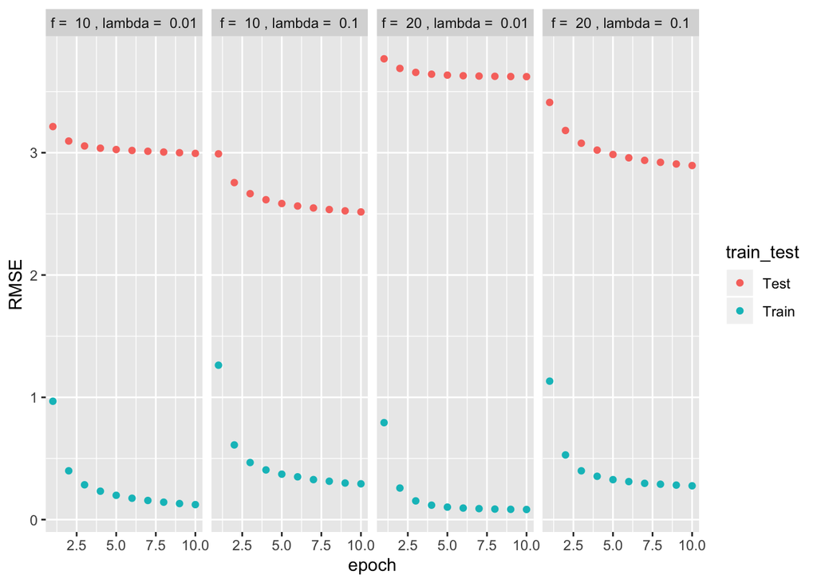

```r
f_list <- seq(10, 20, 10)
l_list <- seq(-2, -1, 1)
f_l <- expand.grid(f_list, l_list)

load(file = "../output/rmse_sgd_5000.Rdata")
rmse <- data.frame(rbind(t(result_summary_sgd_5000[1,,]), t(result_summary_sgd_5000[2,,])), train_test = rep(c("Train", "Test"), each = 4), par = rep(paste("f = ", f_l[,1], ", lambda = ", 10^f_l[,2]), times = 2)) %>% gather("epoch", "RMSE", -train_test, -par)
rmse$epoch <- as.numeric(gsub("X", "", rmse$epoch))
rmse %>% ggplot(aes(x = epoch, y = RMSE, col = train_test)) + geom_point() + facet_grid(~par)
```

##### Step 2.2.2 Tunning parameter for A1 + R1R2 (only 5000 rows)

```r
source("../lib/cross_validation_r1+r2.R")
source("../lib/Matrix_Factorization_r1+r2.R")

f_list <- seq(10, 20, 10)
l_list <- seq(-2, -1, 1)
f_l <- expand.grid(f_list, l_list)

# result_summary_r12 <- array(NA, dim = c(nrow(f_l), 10, 4))
# run_time <- system.time(for(i in 1:nrow(f_l)){
#     par <- paste("f = ", f_l[i,1], ", lambda = ", 10^f_l[i,2])
#     cat(par, "\n")
#     current_result <- cv.function.r12(data[1:5000,], K = 5, f = f_l[i,1], lambda = 10^f_l[i,2])
#     result_summary_r12[,,i] <- matrix(unlist(current_result), ncol = 10, byrow = T)
#     print(result_summary_r12)
#
# })
#
# save(result_summary_r12, file = "../output/rmseR12.Rdata")
```

Plot our tunning parameters for A1 + R1R2 (only 5000 rows)

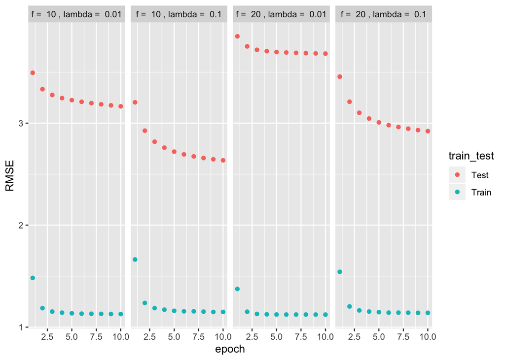

```r
load(file = "../output/rmseR12.Rdata")
rmse <- data.frame(rbind(t(result_summary_r12[1,,]), t(result_summary_r12[2,,])), train_test = rep(c("Train", "Test"), each = 4), par = rep(paste("f = ", f_l[,1], ", lambda = ", 10^f_l[,2]), times = 2)) %>% gather("epoch", "RMSE", -train_test, -par)
rmse$epoch <- as.numeric(gsub("X", "", rmse$epoch))
rmse %>% ggplot(aes(x = epoch, y = RMSE, col = train_test)) + geom_point() + facet_grid(~par)
```

##### Step 2.2.3 Tunning parameter for A1 + R3 (only 5000 rows)

```r
source("../lib/cross_validation_r3.R")
source("../lib/Matrix_Factorization_r3.R")

f_list <- seq(10, 20, 10)
l_list <- seq(-2, -1, 1)
f_l <- expand.grid(f_list, l_list)

# result_summary_r3 <- array(NA, dim = c(nrow(f_l), 10, 4))
# run_time <- system.time(for(i in 1:nrow(f_l)){
#     par <- paste("f = ", f_l[i,1], ", lambda = ", 10^f_l[i,2])
#     cat(par, "\n")
#     current_result <- cv.function.r3(data[1:5000,], K = 5, f = f_l[i,1], lambda = 10^f_l[i,2])
#     result_summary_r3[,,i] <- matrix(unlist(current_result), ncol = 10, byrow = T)
#     print(result_summary_r3)
#
# })
#
# save(result_summary_r3, file = "../output/rmseR3.Rdata")
```

Plot our tunning parameters for A1 + R3 (only 5000 rows)

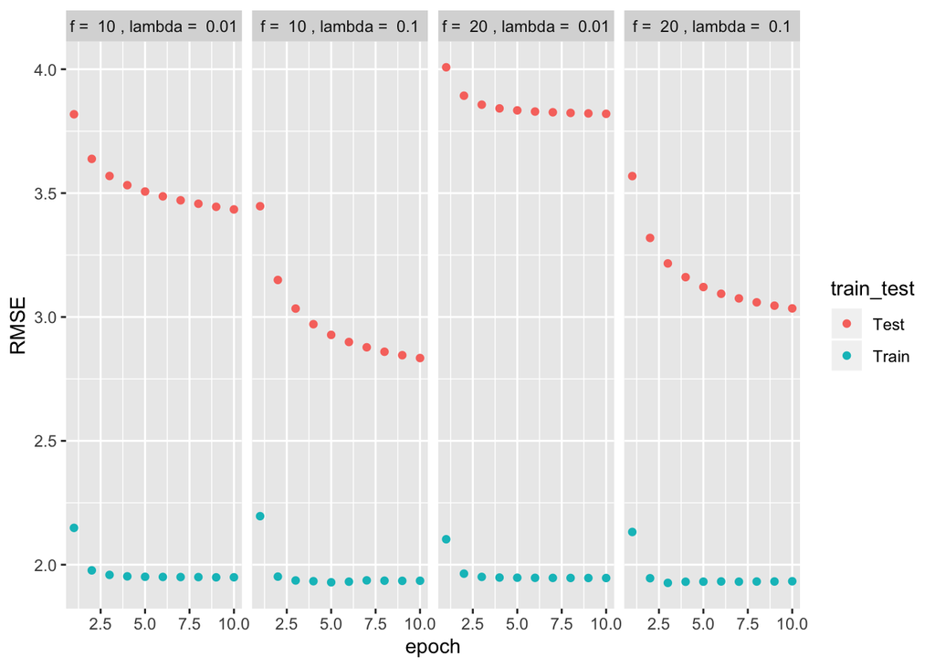

```r
load(file = "../output/rmseR3.Rdata")
rmse <- data.frame(rbind(t(result_summary_r3[1,,]), t(result_summary_r3[2,,])), train_test = rep(c("Train", "Test"), each = 4), par = rep(paste("f = ", f_l[,1], ", lambda = ", 10^f_l[,2]), times = 2)) %>% gather("epoch", "RMSE", -train_test, -par)
rmse$epoch <- as.numeric(gsub("X", "", rmse$epoch))
rmse %>% ggplot(aes(x = epoch, y = RMSE, col = train_test)) + geom_point() + facet_grid(~par)
```

### Step 3 Postprocessing: SVD with KNN

After matrix factorization, postporcessing will be performed to improve accuracy.

RMSE Function

```r
RMSE2 <- function(rating,est_rating){
  sqrt(mean((rating$rating-est_rating)^2))
}
```

KNN Function

```r
vec <- function(x) {

  return(sqrt(sum(x^2)))

  }

pred_knn <- function(data_train, data_test, q)
{

  norm_q <- apply(q,2,vec)
  sim <- t(t((t(q) %*% q)/ norm_q) / norm_q)
  colnames(sim) <- colnames(q)
  rownames(sim) <- colnames(q)
  pred_test <- rep(0,nrow(data_test))

  for (i in 1:nrow(data_test)){
    user_id <- data_test$userId[i]
    movie_id <- data_test$movieId[i]
    train <- data_train[data_train$userId == user_id & data_train$movieId != movie_id,]
    movie_train <- train$movieId
    sim_vec <- sim[rownames(sim) == movie_id, colnames(sim) %in% movie_train]
    movie <- names(sim_vec)[which.max(sim_vec)]
    pred_test[i] <- train[train$movieId == movie,][3]
  }

  pred_test <- as.matrix(unlist(pred_test))
  rmse_test <- sqrt(mean((data_test$rating-pred_test)^2))
  return(list(pred_test = pred_test, rmse_test = rmse_test))

}
```

#### Step 3.1.1 RMSE for A1 (only 5000 rows)

Choose only 5000 rows for train data and test data.

```r
sub_test_idx <- sample(1:5000, 5000/5, 0)
sub_train_idx <- setdiff(1:5000, sub_test_idx)
sub_data_train <- data[sub_train_idx,]
sub_data_test <- data[sub_test_idx,]
```

```r
# result_sgd5000 <- gradesc(f = 10, lambda = 0.1,lrate = 0.01, max.iter = 100, stopping.deriv = 0.01,
#                    data = data[1:5000,], train = sub_data_train, test = sub_data_test)
#
# save(result_sgd5000, file = "../output/mat_fac_sgd5000.RData")

load(file = "../output/rmse_sgd_5000.Rdata")
load(file = "../output/mat_fac_sgd5000.Rdata")

pred_rating <- t(result_sgd5000$q) %*% result_sgd5000$p
rmse_sgd5000 <- RMSE2(sub_data_test,pred_rating)
cat("The RMSE of A1 model with only 5000 rows is", rmse_sgd5000)
```

```
## The RMSE of A1 model with only 5000 rows is 2.663459
```

#### Step 3.1.2 RMSE for A1 + P2 (only 5000 rows)

```r
load(file = "../output/mat_fac_sgd5000.Rdata")
q <- result_sgd5000$q
p2_result_test <- pred_knn(data_train = sub_data_train, data_test = sub_data_test, q)
test_rmse_p2 <- p2_result_test['rmse_test']
cat("The RMSE of A1 with P2 model with only 5000 rows is", as.numeric(test_rmse_p2))
```

```
## The RMSE of A1 with P2 model with only 5000 rows is 1.077033
```

#### Step 3.2.1 RMSE for A1 + R1R2 (only 5000 rows)

```r
# resultr12 <- gradesc.r12(f = 10, lambda = 0.1,lrate = 0.01, max.iter = 100, stopping.deriv = 0.01,
#                    data = data[1:5000,], train = sub_data_train, test = sub_data_test)
#
# save(resultr12, file = "../output/mat_fac_r12.RData")
```

```r
load(file = "../output/mat_fac_r12.RData")

pred_rating <- t(resultr12$q) %*% resultr12$p
rmse_r12 <- RMSE2(sub_data_test,pred_rating)
cat("The RMSE of A1 with R1 R2 model is", rmse_r12)
```

```
## The RMSE of A1 with R1 R2 model is 2.71485
```

#### Step 3.2.2 RMSE for A1 + R1R2 + P2(only 5000 rows)

```r
q <- resultr12$q
p2_result_test <- pred_knn(data_train = sub_data_train, data_test = sub_data_test, q)
test_rmse_p2 <- p2_result_test['rmse_test']
cat("The RMSE of A1 and R1 R2 with P2 model is", as.numeric(test_rmse_p2))
```

```
## The RMSE of A1 and R1 R2 with P2 model is 1.197289
```

#### Step 3.3.1 RMSE for A1 + R3 (only 5000 rows)

```r
# resultr3 <- gradesc.r3(f = 10, lambda = 0.1,lrate = 0.01, max.iter = 100, stopping.deriv = 0.01,
#                    data = data[1:5000,], train = sub_data_train, test = sub_data_test)
#
# save(resultr3, file = "../output/mat_fac_r3.RData")
```

```r
load(file = "../output/mat_fac_r3.RData")

pred_rating <- t(resultr3$q) %*% resultr3$p
rmse_r3 <- RMSE2(sub_data_test,pred_rating)
cat("The RMSE of A1 and R3 model is", rmse_r3)
```

```
## The RMSE of A1 and R3 model is 2.797368
```

#### Step 3.3.2 RMSE for A1 + R3 + P2 (only 5000 rows)

```r
q <- resultr3$q
p2_result_test <- pred_knn(data_train = sub_data_train, data_test = sub_data_test, q)
test_rmse_p2 <- p2_result_test['rmse_test']
cat("The RMSE of A1 and R3 with P2 model is", as.numeric(test_rmse_p2))
```

```
## The RMSE of A1 and R3 with P2 model is 1.283355
```

### Step 4 Evaluation

```r
library(ggplot2)

#SGD (5000 rows)
#RMSE <- data.frame(epochs = seq(10, 100, 10), Training_MSE = result_sgd5000$train_RMSE, Test_MSE = result_sgd5000$test_RMSE) %>% gather(key = train_or_test, value = RMSE, -epochs)

#RMSE %>% ggplot(aes(x = seq(10, 100, 10), y = RMSE,col = train_or_test)) + geom_point() + scale_x_discrete(limits = seq(10, 100, 10)) + xlim(c(0, 100))

#SGD + R1R2
#RMSE <- data.frame(epochs = seq(10, 100, 10), Training_MSE = resultr12$train_RMSE, Test_MSE = resultr12$test_RMSE) %>% gather(key = train_or_test, value = RMSE, -epochs)

#RMSE %>% ggplot(aes(x = epochs, y = RMSE,col = train_or_test)) + geom_point() + scale_x_discrete(limits = seq(10, 100, 10)) + xlim(c(0, 100))

#SGD + R3
#RMSE <- data.frame(epochs = seq(10, 100, 10), Training_MSE = resultr3$train_RMSE, Test_MSE = resultr3$test_RMSE) %>% gather(key = train_or_test, value = RMSE, -epochs)

#RMSE %>% ggplot(aes(x = epochs, y = RMSE,col = train_or_test)) + geom_point() + scale_x_discrete(limits = seq(10, 100, 10)) + xlim(c(0, 100))
```

### Step 5: Conclusions

Because we only use 5000 rows from original data to train our model, so our RMSE is a little bit higher than using the whole dataset.

Test RMSE for A1 : 2.663459

Test RMSE for A1 + P2 : 1.077033

Test RMSE for A1 + R1R2 : 2.71485

Test RMSE for A1 + R1R2 + P2 : 1.197289

Test RMSE for A1 + R3 : 2.797368

Test RMSE for A1 + R3 + P2 : 1.283355

And the best parameters for all models is F = 10, lambda = 0.1 .

After comparing all the results, we find A1 + P2 has the best performance.